# Using Fonts in R: A Comprehensive Guide (Claude 3.7)

### Creating a Font Comparison Plot

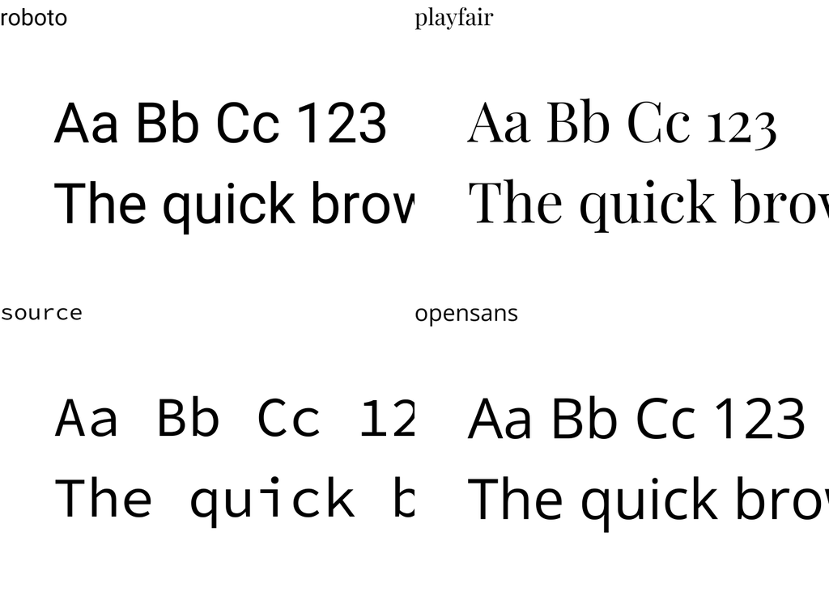

```r
library(ggplot2)
library(showtext)
library(grid)
library(gridExtra)

# Add several fonts
font_add_google("Roboto", "roboto")
font_add_google("Playfair Display", "playfair")
font_add_google("Source Code Pro", "source")
font_add_google("Open Sans", "opensans")
showtext_auto()

# Create a function to generate sample text
font_sample <- function(family, size = 12) {
  ggplot() +
    annotate("text", x = 0, y = 0,
             label = paste0("Aa Bb Cc 123\nThe quick brown fox: ", family),
             family = family, size = size, hjust = 0) +
    xlim(-0.1, 1) + ylim(-0.5, 0.5) +
    theme_void() +
    labs(title = family) +
    theme(plot.title = element_text(family = family, size = 14))
}

# Create sample plots for each font
p1 <- font_sample("roboto")
p2 <- font_sample("playfair")
p3 <- font_sample("source")
p4 <- font_sample("opensans")

# Combine them into a single comparison plot
grid.arrange(p1, p2, p3, p4, ncol = 2)
```

## Resources

### **extrafont**: Import and use system fonts **showtext**: Add and render custom fonts including Google Fonts **ragg**: High-quality graphics device with excellent font support **systemfonts**: Access system fonts

### Further Reading

- [R Graphics Cookbook](https://r-graphics.org/) by Winston Chang
- [ggplot2: Elegant Graphics for Data Analysis](https://ggplot2-book.org/) by Hadley Wickham
- [R Graph Gallery](https://www.r-graph-gallery.com/) for visualization examples
- [Google Fonts](https://fonts.google.com/) for browsing available fonts

### This guide covers the basics of working with fonts in R. Remember that font availability may differ across operating systems, and consider embedding fonts when sharing plots for consistent appearance across devices.